# Prevision de l’etat suivant avec Keras

# 1 **Introduction**

On veut entrainer des modeles sur des sequences d’etats pour predire l’etat suivant. On a donc trois champs :

- *id* : l’identifiant de la sequence
- *num* : le numero de l’etat dans la sequence, la numerotation commence a 1
- *etat* : la valeur de l’etat

Les techniques presentees dans ce document sont appliquees a un jeu de donnees de parcours professionnels. Ainsi le triplet *(id, num, etat) = (“23”, 2, “training”)* indique que l’individu 23 est en stage a la 2eme etape de son parcours. A partir de cette information et des etapes precedentes, on veut predire quelle sera l’activite de l’etape suivante.

Pour realiser cette modelisation, on va couper de maniere aleatoire uniforme les parcours en deux parties “historique” (ou “passe”) et “futur”, le modele connaitra l’historique de chaque sequence et devra predire le premier etat du futur. On va creer aussi des echantillons d’apprentissage et de test. On va utiliser pour cela les champs calcules suivants :

- “long_totale” : la longueur de la sequence complete (dans notre exemple elle est la meme pour tous les parcours mais ca n’intervient pas dans le code)
- “long_histo” : la longueur de l’historique
- “train” : booleen qui indique si la sequence fait partie de l’echantillon d’apprentissage

On aura aussi besoin d’un dictionnaire pour recoder les etats en entiers successifs commencant a zero, c’est un recodage classique attendu par Tensorflow.

## 1.1 Modules

```r
library("reticulate")

# on a installe tensorflow dans l'environnement vituel conda "env_test"
use_condaenv(condaenv = "env_test")

# le jeu de donnees mvad du package R TraMineR
data(package = "TraMineR", mvad)
```

Les modules Python.

```python
import numpy as np
import pandas as pd
import random
import sys

import matplotlib.pyplot as plt
import scikitplot as skplt
import seaborn as sns

import tensorflow as tf
from tensorflow.keras.layers import LSTM, GRU, Dense, Dropout, Embedding
from tensorflow.keras.preprocessing.sequence import pad_sequences
from tensorflow.keras.callbacks import EarlyStopping
from tensorflow.keras.models import Sequential

# https://github.com/philipperemy/keras-tcn
from tcn import TCN

sns.set()
pd.set_option('display.max_columns', None)
tf.random.set_seed(2021)
```

Les versions Python et TensorFlow utilisees.

```python
sys.version
tf.__version__
```

```
'3.9.5 (default, May 18 2021, 14:42:02) [MSC v.1916 64 bit (AMD64)]'
'2.6.0-rc1'
```

## 1.2 Donnees

On a le statut de 712 individus pour 72 mois consecutifs.

- “school” : lycee
- “Further Education” : education continue
- “Higher Education” : universite
- “training” : stage
- “employment” : emploi
- “joblessness” : chomage

La table de recodage des etats et un dictionnaire associe.

```python
recode = pd.DataFrame({"etat": ["training", "joblessness", "school", "employment", "HE", "FE"],
                        "code":  list(range(6))})

recode
```

```
          etat  code
0     training     0
1  joblessness     1
2       school     2
3   employment     3
4           HE     4
5           FE     5
```

```python
dico_recode = {recode.code[i]:recode.etat[i] for i in range(len(recode))}

# on anticipe l'etape de rembourrage par un item supplementaire
dico_recode[len(recode)] = "padding"
dico_recode
```

```
{0: 'training', 1: 'joblessness', 2: 'school', 3: 'employment', 4: 'HE', 5: 'FE', 6: 'padding'}
```

Pour rendre la modelisation moins facile, on ne retient qu’une etape par annee, a savoir celle de juillet. On a donc 6 etapes dans chaque parcours, de 1993 a 1998.

```python
donnees = r.mvad.iloc[:,[0] +list(range(14,86,12))]
donnees = donnees.melt(id_vars = "id", var_name = "mois_annee", value_name = "etat")
donnees.sort_values(["id", "mois_annee"], inplace = True)
donnees[donnees.id == 3]
```

```
      id mois_annee         etat
2      3     Jul.93  joblessness
714    3     Jul.94     training
1426   3     Jul.95     training
2138   3     Jul.96           FE
2850   3     Jul.97           FE
3562   3     Jul.98   employment
```

La preparation des donnees.

```python
donnees["num"] = donnees.groupby("id").cumcount() + 1
donnees.drop(columns = "mois_annee", inplace = True)
donnees["long_totale"] = donnees.groupby("id").etat.transform(len)

table_longueurs = donnees[["id", "long_totale"]].drop_duplicates()

random.seed(2021)
np.random.seed(2021)
table_longueurs["long_histo"] = table_longueurs.long_totale.apply(lambda n: random.randrange(1, n))
table_longueurs.drop(columns = "long_totale", inplace = True)
donnees.drop(columns = "long_totale", inplace = True)

# 60% des individus dans l'echantillon d'apprentissage
table_longueurs["train"] = np.random.rand(len(table_longueurs)) <= 0.6

donnees = donnees.merge(table_longueurs, how = 'left', on = 'id')
donnees.sort_values(["id", "num"], inplace = True)

# on se limite a l'historique et au 1er etat futur
donnees = donnees[donnees.num <= donnees.long_histo + 1][["id", "num", "etat", "long_histo", "train"]]
donnees.head(15)
```

```
    id  num         etat  long_histo  train
0    1    1     training           4  False
1    1    2   employment           4  False
2    1    3   employment           4  False
3    1    4   employment           4  False
4    1    5   employment           4  False
6    2    1  joblessness           5  False
7    2    2           FE           5  False
8    2    3           FE           5  False
9    2    4           FE           5  False
10   2    5           HE           5  False
11   2    6           HE           5  False
12   3    1  joblessness           3   True
13   3    2     training           3   True
14   3    3     training           3   True
15   3    4           FE           3   True
```

Nombre de sequences dans les echantillons d’apprentissage et de test.

```python
donnees[["id", "train"]].drop_duplicates().train.value_counts()
```

```
True     421
False    291
Name: train, dtype: int64
```

# 2 **Modele naif**

```python
stats = donnees.etat[donnees.train & (donnees.num == donnees.long_histo + 1)].value_counts()
stats
modal_max = stats.index[0]

exactitude = (donnees.etat[~donnees.train] == modal_max).mean()
```

```
employment     220
FE              61
HE              40
school          39
joblessness     31
training        30
Name: etat, dtype: int64
```

Modalite la plus frequente de l’etat a predire : employment.

L’exactitude (= “accuracy”) du modele est 35.2%.

Matrice de confusion sur l’echantillon test.

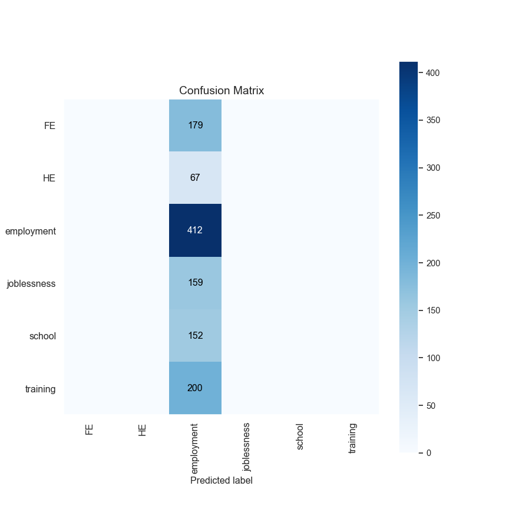

```python
def mat_conf(reel, prev):
  skplt.metrics.plot_confusion_matrix(reel,
                                    prev,
                                    hide_zeros  = True,
                                    x_tick_rotation  = 90,
                                    figsize = (9, 9))
  plt.show()

mat_conf(list(donnees.etat[~donnees.train]), [modal_max]*sum(~donnees.train))
```

# 3 **Chaine de Markov d’ordre *K***

Fonctions de modelisation de la chaine de Markov d’ordre *K*.

```python
# champs pour chaine de Markov d'ordre max K
# on sait que dtf (=donnees) est deja trie par id et num
def prep_markov_K(dtf,K):
  prep_markov = dtf.copy()
  for i in range(K):
    condition = prep_markov.id != prep_markov.id.shift(i+1)
    prep_markov["etat_moins_"+str(i+1)] = prep_markov.etat.shift(i+1)
    prep_markov.loc[condition, "etat_moins_"+str(i+1)] = ''
  return prep_markov

# cette fonction va etre appliquee a la sortie de prep_markov_K
def modele_markov(dtf, K):
  # a chaque page, on associe la liste des K pages precedentes
  markov = dtf.copy()

  u =  markov["etat_moins_1"]
  for i in range(K-1):
    u = u + ',' + markov["etat_moins_"+str(i+2)]

  markov["pages_prec"] = u

  # construction du modele de Markov
  score_markov = markov[markov.train].copy()
  score_markov = score_markov.groupby(["pages_prec", "etat"]).size().reset_index(name = "nb")

  score_markov["somme"] = score_markov.groupby("pages_prec").nb.transform("sum")
  score_markov["pct"] = score_markov.nb / score_markov.somme

  # pour chaque combinaison de pages precedentes, on va garder la ligne de score max
  score_markov.sort_values(["somme", "pages_prec", "pct"],
                           ascending = [False,True, False], inplace = True)

  prev_markov = score_markov.groupby(
      "pages_prec", as_index = False).first()[["pages_prec", "etat"]].rename(columns = {"etat" : "prev"})

  # application a l'echantillon test
  test_markov =  markov[(~markov.train) & (markov.num == markov.long_histo + 1)].copy()
  test_markov = test_markov.merge(prev_markov, how = "left", on = "pages_prec")

  exactitude = (test_markov.prev == test_markov.etat).mean()
  reel = list(test_markov["etat"])
  prev = list(test_markov["prev"])
  return exactitude, score_markov[["pages_prec", "etat", "pct"]], reel, prev
```

## 3.1 Ordre optimal

On cherhe la valeur de *K* qui maximise l’exactitude.

```python
dtf_markov = prep_markov_K(donnees,5)

exactitude1, _, _, _ = modele_markov(dtf_markov, K = 1)
exactitude2, _, _, _ = modele_markov(dtf_markov, K = 2)
exactitude3, _, _, _ = modele_markov(dtf_markov, K = 3)
exactitude4, _, _, _ = modele_markov(dtf_markov, K = 4)
exactitude5, _, _, _ = modele_markov(dtf_markov, K = 5)

pd.Series([exactitude1, exactitude2, exactitude3, exactitude4, exactitude5]).apply(lambda x: round(x,3))
```

```
0    0.605
1    0.622
2    0.629
3    0.574
4    0.505
dtype: float64
```

On retient le modele d’ordre 3.

```python
exactitude, modele_markov3, reel, prev = modele_markov(dtf_markov, K = 3)
```

## 3.2 Matrice de confusion

L’exactitude du modele d’ordre 3 est 62.9%.

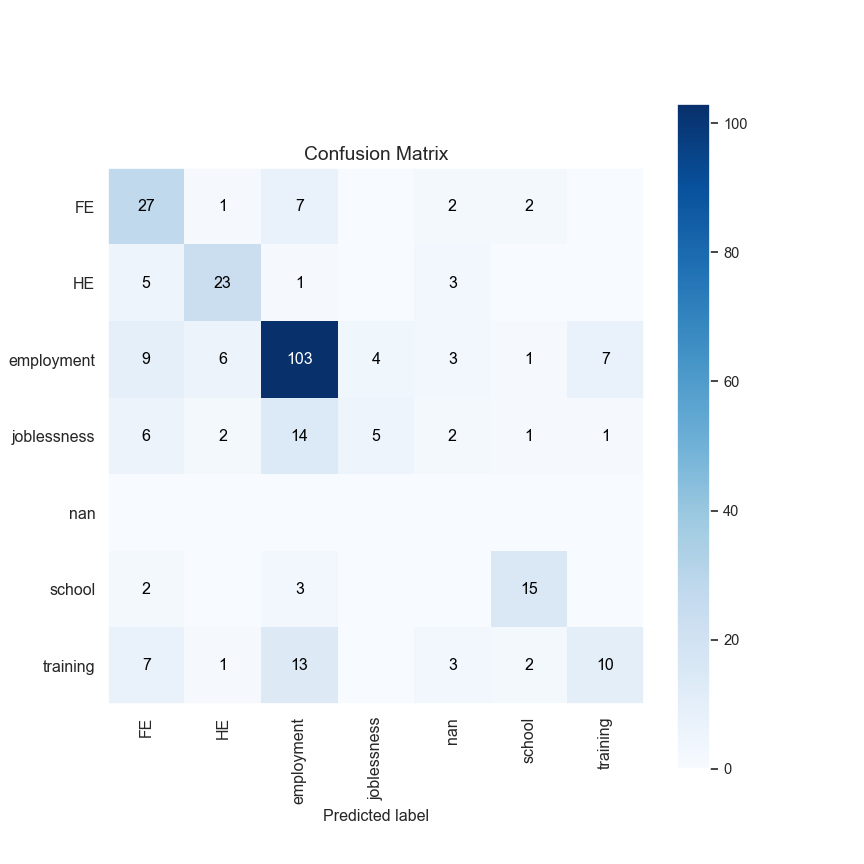

```python
mat_conf(reel, prev)
```

# 4 **Preparation des modeles neuronaux**

On utilise les couches LSTM (Long Short-Term Memory), GRU (Gated Recurrent Unit) et TCN (Temporal Convolution Network). Les deux 1ers types d’architecture utilisent des etats caches, le modele GRU etant plus recent, moins complexe et ausi performant que le modele LSTM. L’approche TCN evite les etats caches et utilise les methodes du traitement d’images, elle peut etre aussi performante que les deux autres methodes.

## 4.1 Preparation des donnees

Choix d’hyperparametres : la taille des mini-batchs, le nombres d’epoques, le % de donnees utilisees pour validation.

```python
taille_batch =  8
nb_epoques = 150
taux_val = 0.4
```

Pour chaque *id*, on met l’historique du parcours dans une liste et la cible dans une seconde colonne.

```python
sequences = donnees.copy()
sequences = sequences.merge(recode[["code", "etat"]], how = 'left', on = "etat")
sequences.sort_values(["id", "num"], inplace = True)

listes = sequences[sequences.num <= sequences.long_histo].groupby(
  "id").code.apply(list).reset_index().rename(columns = {"code": "pages_prec"})
cibles = sequences[sequences.num == sequences.long_histo + 1][
  ["id", "train", "code"]].rename(columns = {"code": "cible"})
sequences = pd.merge(listes, cibles, how = 'left', on = 'id')

sequences = sequences[["id", "train", "pages_prec", "cible"]]

nb_sequences = len(sequences)
long_max = sequences.pages_prec.apply(len).max()

sequences
```

```
      id  train       pages_prec  cible
0      1  False     [0, 3, 3, 3]      3
1      2  False  [1, 5, 5, 5, 4]      4
2      3   True        [1, 0, 0]      5
3      4   True           [0, 0]      0
4      5  False              [1]      5
..   ...    ...              ...    ...
707  708  False        [5, 5, 3]      3
708  709  False     [5, 1, 1, 1]      1
709  710   True        [2, 1, 5]      3
710  711  False  [0, 0, 3, 3, 3]      3
711  712  False           [0, 0]      0

[712 rows x 4 columns]
```

Rembourrage et redimensionnement des sequences : on doit fournir un tenseur a 3 dimensions comme predicteur d’entree aux couches LSTM, GRU ou TCN.

- 1er axe : les exemples, ici une sequence est un exemple, la valeur du tenseur sur le 1er axe est donc 712 (apprentissage et test confondus).
- 2eme axe : le pas temporel. La valeur sur cet axe est 5, c’est le nombre d’etapes maximal de chaque sequence, il doit etre le meme pour chaque sequence. On utilise ci-dessous la fonction *pad_sequences* pour rembourrer a gauche chaque sequence a la longueur voulue.
- 3eme axe : les caracteristiques d’un element d’une sequence, ici chaque etat est simplement code sous forme d’un entier, la valeur du tenseur est donc 1. Si chaque etat etait represente par un *array numpy* de longueur *n*, la valeur du tenseur serait *n* (cf couche Embedding dans la suite du document, on aura alors *n = 3* a la sortie de cette couche).

Pour la cible, le pas temporel n’a pas de sens et c’est donc un tenseur a deux dimensions qui est attendu.

```python
histo_train = list(sequences.pages_prec[sequences.train])
histo_train = pad_sequences(histo_train, maxlen = long_max, padding='pre', value=len(recode), dtype="float32")
histo_train = np.reshape(histo_train, (len(histo_train), long_max, 1))

histo_test = list(sequences.pages_prec[~sequences.train])
histo_test = pad_sequences(histo_test, maxlen = long_max, padding='pre', value = len(recode), dtype="float32")
histo_test = np.reshape(histo_test, (len(histo_test), long_max, 1))

cible_train = list(sequences.cible[sequences.train])
cible_train = np.reshape(cible_train, (len(cible_train), 1))

cible_test = np.array(sequences.cible[~sequences.train])
```

Exemple de sequence completee a gauche.

```python
np.array(pd.Series(histo_train[0,:,0]).map(dico_recode))
```

```
array(['padding', 'padding', 'joblessness', 'training', 'training'],
      dtype=object)
```

## 4.2 Early stopping et graphiques de performance

Si la perte ne diminue plus sur l’echantillon de validation (“val_loss”) lors d’une succession de 10 epoques, l’entrainement s’arrete et revient a la meilleure perte observee.

```python
early_stopping = EarlyStopping(
    monitor = 'val_loss',
    verbose = 1,
    patience = 10,
    restore_best_weights = True)
```

Graphiques qui permettent de detecter le surapprentissage du modele (courbe de perte pour la validation superieure a celle de l’apprentissage) et l’evolution de la metrique “metier”, ici l’exactitude.

```python
def perf(histoire):
  dtf = pd.DataFrame(histoire.history)
  colonnes = dtf.columns

  dtf = dtf.reset_index().rename(columns = {'index': 'epochs'})
  dtf_tr = pd.melt(dtf, id_vars = ['epochs'], value_vars = colonnes,
    var_name ='noms_col', value_name='valeurs_col')

  dtf_tr["metrique"] = dtf_tr.noms_col.str.replace("^val_", "", regex = True)
  dtf_tr["echantillon"] = "val"
  dtf_tr.loc[dtf_tr.noms_col == dtf_tr.metrique, "echantillon"] = "train"

  g = sns.FacetGrid(dtf_tr, col="metrique", hue = "echantillon", sharey = False, col_wrap = 2)
  g = g.map_dataframe(sns.lineplot, x = "epochs",y = "valeurs_col").add_legend()
  plt.show()
```

# 5 **Modeles avec couche LSTM / GRU**

## 5.1 Architecture et entrainement des modeles

Chaque couche “Dropout” s’applique a la couche precedente et permet de diminuer le risque de surapprentissage.

### 5.1.1 LSTM

```python
model_lstm = Sequential()
model_lstm.add(LSTM(10))
model_lstm.add(Dropout(0.5))
model_lstm.add(Dense(len(recode), activation='softmax'))

model_lstm.compile(loss = 'sparse_categorical_crossentropy', metrics = ['accuracy'])
```

```python
history_lstm = model_lstm.fit(histo_train,
                     cible_train,
                     epochs = nb_epoques,
                     batch_size = taille_batch,
                     verbose = 1,
                     validation_split = taux_val,
                     callbacks = [early_stopping])
```

### 5.1.2 GRU

```python
model_gru = Sequential()
model_gru.add(GRU(10))
model_gru.add(Dropout(0.5))
model_gru.add(Dense(len(recode), activation='softmax'))

model_gru.compile(loss = 'sparse_categorical_crossentropy', metrics = ['accuracy'])
```

```python
history_gru = model_gru.fit(histo_train,
                     cible_train,
                     epochs = nb_epoques,
                     batch_size = taille_batch,
                     verbose = 1,
                     validation_split = taux_val,
                     callbacks = [early_stopping])
```

## 5.2 Performance lors de l’entrainement

On voit que l’early stopping ne s’est jamais declenche car la perte diminue regulierement, par contre la metrique “exactitude” plafonne assez vite.

### 5.2.1 LSTM

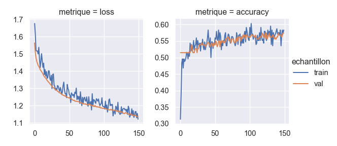

```python
perf(history_lstm)
```

On recupere les previsions sur l’echantillon test.

```python
predictions = model_lstm.predict(histo_test)
predictions.round(2)[:5]

# pour chaque exemple on retient la colonne de score maximal
prev = pd.DataFrame(predictions)
prev_lstm = np.array(prev.idxmax(axis = 'columns'))

exactitude_lstm = (prev_lstm == cible_test).mean()
```

```
array([[0.  , 0.04, 0.03, 0.74, 0.15, 0.04],
       [0.01, 0.05, 0.02, 0.57, 0.14, 0.21],
       [0.22, 0.07, 0.22, 0.34, 0.02, 0.13],
       [0.  , 0.04, 0.02, 0.72, 0.18, 0.04],
       [0.22, 0.07, 0.22, 0.34, 0.02, 0.13]], dtype=float32)
```

### 5.2.2 GRU

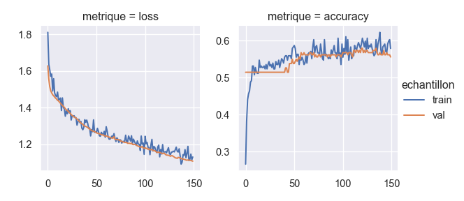

```python
perf(history_gru)
```

```python
predictions = model_gru.predict(histo_test)
prev = pd.DataFrame(predictions)
prev_gru = np.array(prev.idxmax(axis = 'columns'))

exactitude_gru = (prev_gru == cible_test).mean()
```

## 5.3 Matrice de confusion

Les modeles obtenus sont moins performants que la chaine de Markov d’ordre 1 (!), l’explication sera donne dans la section suivante. En outre les etats “joblessness” et “HE” ne sont jamais predits.

### 5.3.1 LSTM

L’exactitude du modele LSTM est 50.5%.

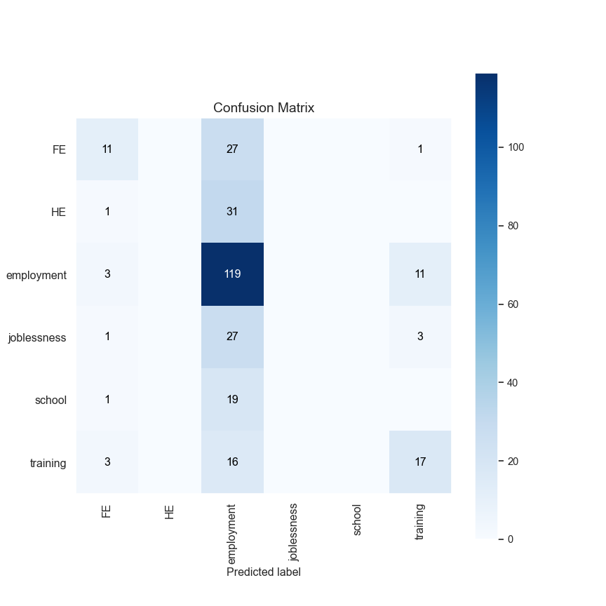

```python
mat_conf(pd.Series(cible_test).map(dico_recode), pd.Series(prev_lstm).map(dico_recode))
```

### 5.3.2 GRU

L’exactitude du modele GRU est 50.5%.

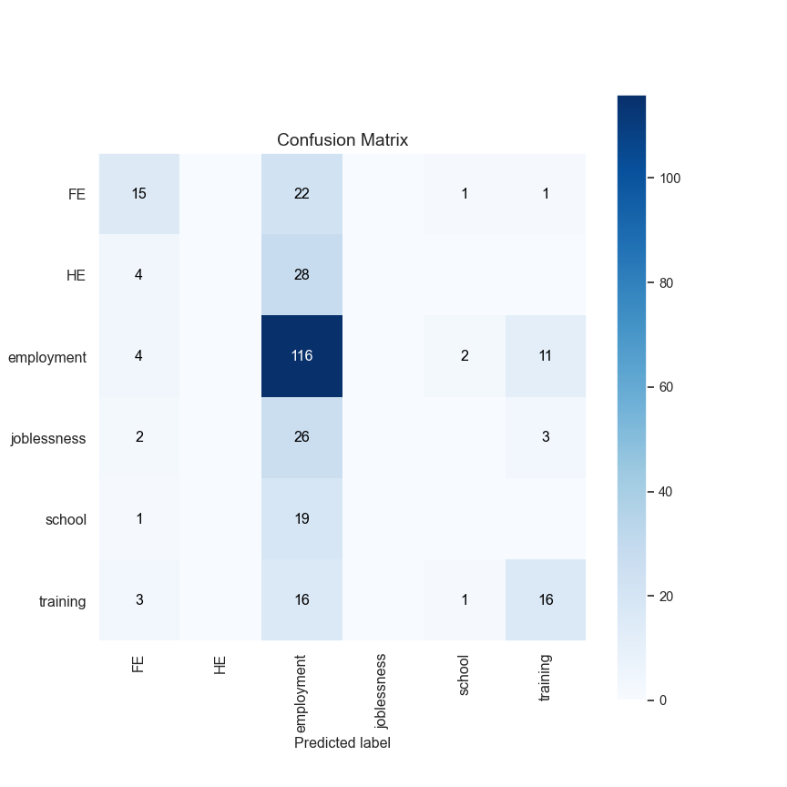

```python
mat_conf(pd.Series(cible_test).map(dico_recode), pd.Series(prev_gru).map(dico_recode))
```

# 6 **Modeles avec Embedding et couche GRU / TCN**

## 6.1 Architecture et entrainement des modeles

Ici on rajoute une couche Embedding. En effet dans la section precedente les couches LSTM et GRU avaient en entree des listes d’entiers qui etaient un recodage arbitraire des etats. Ce recodage ne refletait pas une proximite metier entre les etats codes par 0 et 1, ou un ecart metier entre les etats codes par 0 et 5. La couche Embedding permet de transformer chacun de ces entiers en un vecteur qui va etre optimise pour la tache a realiser. La couche Embedding va donc traduire (au moins en partie) une proximite metier en proximite numerique entre les differents vecteurs en entree de la couche GRU ou TCN.

### 6.1.1 GRU

```python
model_gru2 = Sequential()
model_gru2.add(
    Embedding(
        input_dim = 1+len(recode), # taille du vocabulaire + padding
        output_dim = 3, # dimension choisie des vecteurs d'etat
        input_length = long_max # longueur des sequences
    )
)
model_gru2.add(Dropout(0.3))
model_gru2.add(GRU(20))
model_gru2.add(Dropout(0.3))
model_gru2.add(Dense(len(recode), activation='softmax'))

model_gru2.compile(loss = 'sparse_categorical_crossentropy', metrics = ['accuracy'])
```

```python
history_gru2 = model_gru2.fit(histo_train,
                     cible_train,
                     epochs = nb_epoques,
                     batch_size = taille_batch,
                     verbose = 1,
                     validation_split = taux_val,
                     callbacks = [early_stopping])
```

```
Restoring model weights from the end of the best epoch.
Epoch 00128: early stopping
```

### 6.1.2 TCN

```python
time_steps = 1
input_dim = long_max

tcn_layer = TCN(input_shape = (time_steps, input_dim),
                nb_filters = 20,
                kernel_size = 2,
                dilations = (1, 2),
                return_sequences = False)

print('Receptive field size =', tcn_layer.receptive_field)

model_tcn = Sequential()
model_tcn.add(
    Embedding(
        input_dim = 1+len(recode),
        output_dim = 3,
        input_length = long_max
    )
)
model_tcn.add(Dropout(0.3))
model_tcn.add(tcn_layer)
model_tcn.add(Dropout(0.3))
model_tcn.add(Dense(len(recode), activation='softmax'))

model_tcn.compile(loss = 'sparse_categorical_crossentropy', metrics = ['accuracy'])
```

```
Receptive field size = 7
```

```python
history_tcn = model_tcn.fit(histo_train,
                     cible_train,
                     epochs = nb_epoques,
                     batch_size = taille_batch,
                     verbose = 1,
                     validation_split = taux_val,
                     callbacks = [early_stopping])
```

```
Restoring model weights from the end of the best epoch.
Epoch 00048: early stopping
```

## 6.2 Performance lors de l’entrainement

Cette fois le early stopping a permis d’accelerer l’entrainement des modeles.

### 6.2.1 GRU

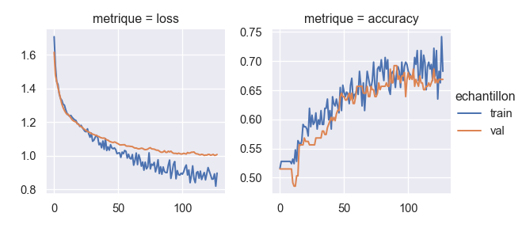

```python
perf(history_gru2)
```

```python
predictions = model_gru2.predict(histo_test)
prev = pd.DataFrame(predictions)
prev_gru2 = np.array(prev.idxmax(axis = 'columns'))

exactitude_gru2 = (prev_gru2 == cible_test).mean()
```

### 6.2.2 TCN

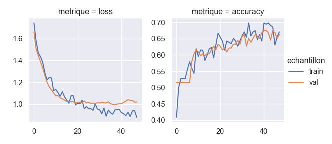

```python
perf(history_tcn)
```

```python
predictions = model_tcn.predict(histo_test)
prev = pd.DataFrame(predictions)
prev_tcn = np.array(prev.idxmax(axis = 'columns'))

exactitude_tcn = (prev_tcn == cible_test).mean()
```

## 6.3 Matrice de confusion

Les deux modeles approchent voire egalent la performance de la chaine de Markov. Pour le modele GRU on voit ainsi l’interet de la couche Embedding. Mais la faible longueur des sequences utilisees ici et leur petit nombre ne permet pas aux reseaux de neurones de depasser significativement ce niveau de performance.

### 6.3.1 GRU

L’exactitude du modele GRU est 60.5%.

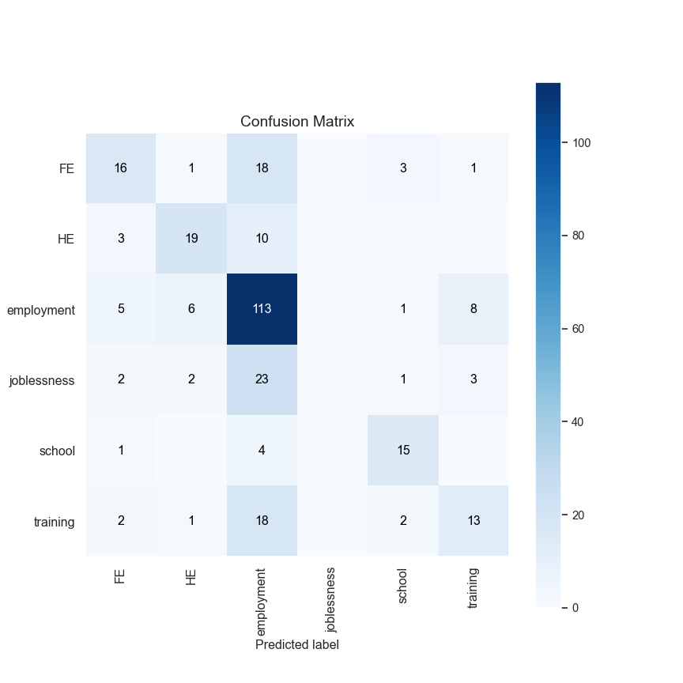

```python
mat_conf(pd.Series(cible_test).map(dico_recode), pd.Series(prev_gru2).map(dico_recode))
```

### 6.3.2 TCN

L’exactitude du modele TCN est 63.6%.

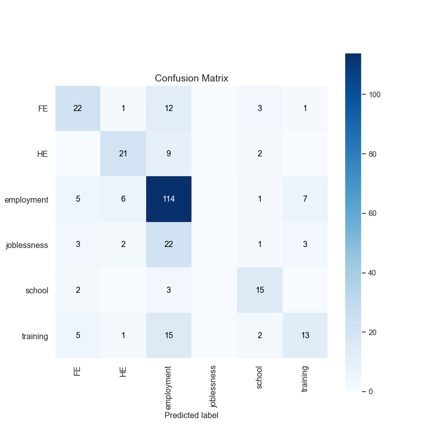

```python
mat_conf(pd.Series(cible_test).map(dico_recode), pd.Series(prev_tcn).map(dico_recode))
```

**retour au debut du document**